# Notebook 06: Perform Pathway Enrichment Analysis

Author

Shirshak Aryal

Published

July 3, 2026

Perform **Pathway Enrichment analysis** using the **DE results from Notebook 05**. The primary purpose of pathway enrichment analysis in this project is to **identify biological processes and signaling pathways that differ between Proneural (PN) and Mesenchymal (ME)** GBM subtypes, using two complementary approaches:

- **ORA (Over-Representation Analysis)**: tests **whether specific pathways are overrepresented** among genes already identified as significantly differentially expressed.
- **GSEA (Gene Set Enrichment Analysis)**: tests for **subtle, coordinated shifts in expression levels across the full set of genes**, without requiring a pre-filtered significant gene list.

Both approaches are run using the **DE results from Notebook 05, i.e.** **DESeq2 (primary) and EdgeR (confirmatory) results independently**, and **only consensus results are retained**. That is, **only the pathways from DESeq2 lists are retained**, that too **only if they are also significant in EdgeR lists**.

## 1. Import Libraries

```r
library(tidyverse)        # data manipulation and visualisation
library(patchwork)        # combine multiple ggplot2 plots into one canvas
library(clusterProfiler)  # gene set enrichment and pathway analysis
library(org.Hs.eg.db)     # human gene annotation database
library(enrichplot)       # visualisation of enrichment results

cat("\nLibraries loaded successfully\n")
```

```
Libraries loaded successfully
```

```r
cat("tidyverse version:       ", as.character(packageVersion("tidyverse")), "\n")
```

```
tidyverse version:        2.0.0
```

```r
cat("patchwork version:       ", as.character(packageVersion("patchwork")), "\n")
```

```
patchwork version:        1.3.2
```

```r
cat("clusterProfiler version: ", as.character(packageVersion("clusterProfiler")), "\n")
```

```
clusterProfiler version:  4.18.4
```

```r
cat("org.Hs.eg.db version:    ", as.character(packageVersion("org.Hs.eg.db")), "\n")
```

```
org.Hs.eg.db version:     3.22.0
```

```r
cat("enrichplot version:      ", as.character(packageVersion("enrichplot")), "\n")
```

```
enrichplot version:       1.30.4
```

## 2. Load DE Results

```r
deseq2_results <- readRDS("../04_results/05_de_analysis/01_deseq2_full_results.rds")
edger_results <- readRDS("../04_results/05_de_analysis/02_edger_full_results.rds")

cat("DESeq2 full results loaded:", nrow(deseq2_results), "genes\n")
```

```
DESeq2 full results loaded: 16164 genes
```

```r
cat("EdgeR full results loaded:", nrow(edger_results), "genes\n")
```

```
EdgeR full results loaded: 16164 genes
```

## 3. Perform Pathway Enrichment Analysis

Both ORA and GSEA are performed against **two pathway databases**:

- **GO:BP (Gene Ontology: Biological Process)**: a database maintained by the **GO Consortium** that annotates genes to **specific biological activities** such as glial cell differentiation, neural stem cell proliferation, apoptotic process, DNA repair, and so on.
- **KEGG (Kyoto Encyclopedia of Genes and Genomes)**: a database maintained by **Kyoto University** that maps genes to **known metabolic and signaling pathways** such as glioma development signaling, tumor suppressor signaling, and so on.

Using both databases **ensures that findings are not an artifact of any single annotation system,** and allows **cross-validation of enriched biological themes** across two independently curated pathway catalogs.

### 3.1. Perform ORA

**Over-Representation Analysis (ORA)** tests **whether** **genes from a pre-defined, biologically-relevant set (i.e. a pathway)** **appear more often in a given gene list** than would be expected by chance.

ORA is run **separately on DESeq2’s and EdgeR’s gene lists**, and **only consensus results are retained**. That is, **only the pathways from DESeq2 lists are retained**, that too **only if they are also significant in EdgeR lists**.

#### 3.1.1. Split DE Results Into Upregulated And Downregulated Genes

```r
# split DESeq2 full results into upregulated and downregulated gene lists
# consistent with NB05's significance thresholds: padj < 0.05, |log2FC| > 1
deseq2_up   <- deseq2_results %>%
  filter(padj < 0.05, log2FoldChange > 1) %>%
  rownames_to_column(var = "ensembl_id") %>%
  pull(ensembl_id)

deseq2_down <- deseq2_results %>%
  filter(padj < 0.05, log2FoldChange < -1) %>%
  rownames_to_column(var = "ensembl_id") %>%
  pull(ensembl_id)



# split EdgeR full results into upregulated and downregulated gene lists
# consistent with NB05's significance thresholds: padj < 0.05, |log2FC| > 1
edger_up   <- edger_results %>%
  filter(FDR < 0.05, logFC > 1) %>%
  rownames_to_column(var = "ensembl_id") %>%
  pull(ensembl_id)

edger_down <- edger_results %>%
  filter(FDR < 0.05, logFC < -1) %>%
  rownames_to_column(var = "ensembl_id") %>%
  pull(ensembl_id)



cat("DESeq2 upregulated genes:  ", length(deseq2_up), "\n")
```

```
DESeq2 upregulated genes:   1553
```

```r
cat("DESeq2 downregulated genes:", length(deseq2_down), "\n")
```

```
DESeq2 downregulated genes: 1163
```

```r
cat("EdgeR upregulated genes:   ", length(edger_up), "\n")
```

```
EdgeR upregulated genes:    1587
```

```r
cat("EdgeR downregulated genes: ", length(edger_down), "\n")
```

```
EdgeR downregulated genes:  1162
```

#### 3.1.2. Enrich Using GO:BP Database

##### 3.1.2.1. Enrich Upregulated And Downregulated Genes

```r
# strip Ensembl version suffixes before enrichment
deseq2_up_ids   <- gsub("\\..*", "", deseq2_up)
deseq2_down_ids <- gsub("\\..*", "", deseq2_down)
edger_up_ids    <- gsub("\\..*", "", edger_up)
edger_down_ids  <- gsub("\\..*", "", edger_down)



# ORA on DESeq2 upregulated genes
ora_deseq2_up_go <- enrichGO(
  gene          = deseq2_up_ids,  # DESeq2 upregulated gene list
  OrgDb         = org.Hs.eg.db,   # human gene annotation database
  keyType       = "ENSEMBL",      # gene identifiers are in Ensembl ID format
  ont           = "BP",           # test against the GO Biological Process (BP) database

  pAdjustMethod = "BH",           # correct for multiple testing using Benjamini-Hochberg FDR correction
  pvalueCutoff  = 0.05,           # only consider p-values < 0.05 as significant

  readable      = TRUE            # convert Ensembl IDs to gene symbols in the output
)

# ORA on EdgeR upregulated genes
ora_edger_up_go <- enrichGO(
  gene          = edger_up_ids,   # EdgeR upregulated gene list
  OrgDb         = org.Hs.eg.db,   # human gene annotation database
  keyType       = "ENSEMBL",      # gene identifiers are in Ensembl ID format
  ont           = "BP",           # test against the GO Biological Process (BP) database

  pAdjustMethod = "BH",           # correct for multiple testing using Benjamini-Hochberg FDR correction
  pvalueCutoff  = 0.05,           # only consider p-values < 0.05 as significant

  readable      = TRUE            # convert Ensembl IDs to gene symbols in the output
)




# ORA on DESeq2 downregulated genes
ora_deseq2_down_go <- enrichGO(
  gene          = deseq2_down_ids,  # DESeq2 downregulated gene list
  OrgDb         = org.Hs.eg.db,     # human gene annotation database
  keyType       = "ENSEMBL",        # gene identifiers are in Ensembl ID format
  ont           = "BP",             # test against the GO Biological Process (BP) database

  pAdjustMethod = "BH",             # correct for multiple testing using Benjamini-Hochberg FDR correction
  pvalueCutoff  = 0.05,             # only consider p-values < 0.05 as significant

  readable      = TRUE              # convert Ensembl IDs to gene symbols in the output
)

# ORA on EdgeR downregulated genes
ora_edger_down_go <- enrichGO(
  gene          = edger_down_ids,  # EdgeR downregulated gene list
  OrgDb         = org.Hs.eg.db,    # human gene annotation database
  keyType       = "ENSEMBL",       # gene identifiers are in Ensembl ID format
  ont           = "BP",            # test against the GO Biological Process (BP) database

  pAdjustMethod = "BH",            # correct for multiple testing using Benjamini-Hochberg FDR correction
  pvalueCutoff  = 0.05,            # only consider p-values < 0.05 as significant

  readable      = TRUE             # convert Ensembl IDs to gene symbols in the output
)



cat("ORA GO:BP results:\n")
```

```
ORA GO:BP results:
```

```r
cat("DESeq2 upregulated:   ", nrow(ora_deseq2_up_go@result %>% filter(p.adjust < 0.05)), "significant terms\n")
```

```
DESeq2 upregulated:    1338 significant terms
```

```r
cat("EdgeR upregulated:    ", nrow(ora_edger_up_go@result %>% filter(p.adjust < 0.05)), "significant terms\n\n")
```

```
EdgeR upregulated:     1346 significant terms
```

```r
cat("DESeq2 downregulated: ", nrow(ora_deseq2_down_go@result %>% filter(p.adjust < 0.05)), "significant terms\n")
```

```
DESeq2 downregulated:  504 significant terms
```

```r
cat("EdgeR downregulated:  ", nrow(ora_edger_down_go@result %>% filter(p.adjust < 0.05)), "significant terms\n")
```

```
EdgeR downregulated:   480 significant terms
```

##### 3.1.2.2. Extract Consensus Results

```r
# intersect by pathway ID, retain DESeq2's full result rows as primary statistics
ora_consensus_up_go <- ora_deseq2_up_go@result %>%
  filter(p.adjust < 0.05) %>%
  filter(ID %in% (ora_edger_up_go@result %>% filter(p.adjust < 0.05) %>% pull(ID)))

ora_consensus_down_go <- ora_deseq2_down_go@result %>%
  filter(p.adjust < 0.05) %>%
  filter(ID %in% (ora_edger_down_go@result %>% filter(p.adjust < 0.05) %>% pull(ID)))

cat("Consensus ORA GO:BP terms before removing redundant ones:\n")
```

```
Consensus ORA GO:BP terms before removing redundant ones:
```

```r
cat("Upregulated:  ", nrow(ora_consensus_up_go), "\n")
```

```
Upregulated:   1284
```

```r
cat("Downregulated:", nrow(ora_consensus_down_go), "\n")
```

```
Downregulated: 470
```

```r
# remove redundant GO terms using semantic similarity
set.seed(42)
ora_consensus_up_go   <- simplify(
  new("enrichResult", result = ora_consensus_up_go, ontology = "BP")
)@result

set.seed(42)
ora_consensus_down_go <- simplify(
  new("enrichResult", result = ora_consensus_down_go, ontology = "BP")
)@result

cat("\nConsensus ORA GO:BP terms after removing redundant ones:\n")
```

```
Consensus ORA GO:BP terms after removing redundant ones:
```

```r
cat("Upregulated:  ", nrow(ora_consensus_up_go), "\n")
```

```
Upregulated:   390
```

```r
cat("Downregulated:", nrow(ora_consensus_down_go), "\n")
```

```
Downregulated: 164
```

```r
cat("\nTop 10 consensus upregulated GO:BP terms:\n")
```

```
Top 10 consensus upregulated GO:BP terms:
```

```r
ora_consensus_up_go %>%
  arrange(p.adjust) %>%
  dplyr::select(Description, p.adjust, Count) %>%
  mutate(p.adjust = formatC(p.adjust, format = "e", digits = 2)) %>%
  head(10) %>%
  knitr::kable()
```

|  | Description | p.adjust | Count |
| --- | --- | --- | --- |
| GO:0050900 | leukocyte migration | 2.62e-42 | 128 |
| GO:0060326 | cell chemotaxis | 1.44e-33 | 105 |
| GO:0070661 | leukocyte proliferation | 2.12e-28 | 108 |
| GO:0002685 | regulation of leukocyte migration | 1.62e-27 | 80 |
| GO:0002274 | myeloid leukocyte activation | 3.15e-27 | 86 |
| GO:0030198 | extracellular matrix organization | 3.45e-26 | 94 |
| GO:0046651 | lymphocyte proliferation | 2.87e-25 | 96 |
| GO:0070663 | regulation of leukocyte proliferation | 7.18e-25 | 92 |
| GO:0030217 | T cell differentiation | 1.24e-23 | 89 |
| GO:0050729 | positive regulation of inflammatory response | 2.27e-23 | 66 |

```r
cat("\nTop 10 consensus downregulated GO:BP terms:\n")
```

```
Top 10 consensus downregulated GO:BP terms:
```

```r
ora_consensus_down_go %>%
  arrange(p.adjust) %>%
  dplyr::select(Description, p.adjust, Count) %>%
  mutate(p.adjust = formatC(p.adjust, format = "e", digits = 2)) %>%
  head(10) %>%
  knitr::kable()
```

|  | Description | p.adjust | Count |
| --- | --- | --- | --- |
| GO:0021953 | central nervous system neuron differentiation | 1.24e-15 | 53 |
| GO:0060078 | regulation of postsynaptic membrane potential | 1.24e-15 | 42 |
| GO:0007416 | synapse assembly | 1.24e-15 | 58 |
| GO:0050803 | regulation of synapse structure or activity | 1.89e-15 | 63 |
| GO:0007409 | axonogenesis | 2.36e-15 | 75 |
| GO:0098742 | cell-cell adhesion via plasma-membrane adhesion molecules | 4.60e-15 | 58 |
| GO:0050807 | regulation of synapse organization | 2.09e-14 | 60 |
| GO:0006334 | nucleosome assembly | 5.03e-14 | 36 |
| GO:0034728 | nucleosome organization | 8.85e-13 | 37 |
| GO:0061644 | protein localization to CENP-A containing chromatin | 1.72e-11 | 13 |

##### 3.1.2.3. Plot Consensus Results

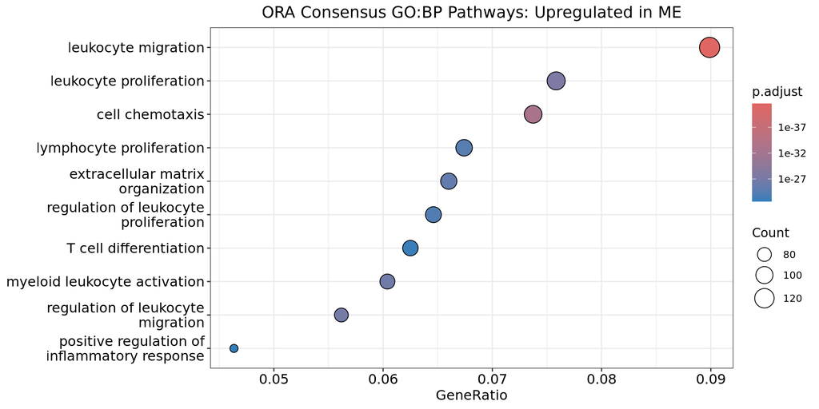

```r
# convert into dotplot()-compatible objects
ora_consensus_up_go_enrich <- new("enrichResult", result = ora_consensus_up_go)
ora_consensus_down_go_enrich <- new("enrichResult", result = ora_consensus_down_go)



# plot top 10 consensus upregulated GO:BP terms
ora_consensus_up_go_plot   <- dotplot(
  ora_consensus_up_go_enrich,
  showCategory = 10,
  title = "ORA Consensus GO:BP Pathways: Upregulated in ME"
) +
theme(plot.title = element_text(hjust = 0.5, size = 14))


# plot top 10 consensus downregulated GO:BP terms
ora_consensus_down_go_plot   <- dotplot(
  ora_consensus_down_go_enrich,
  showCategory = 10,
  title = "ORA Consensus GO:BP Pathways: Downregulated in ME"
) +
theme(plot.title = element_text(hjust = 0.5, size = 14))



ora_consensus_up_go_plot
```

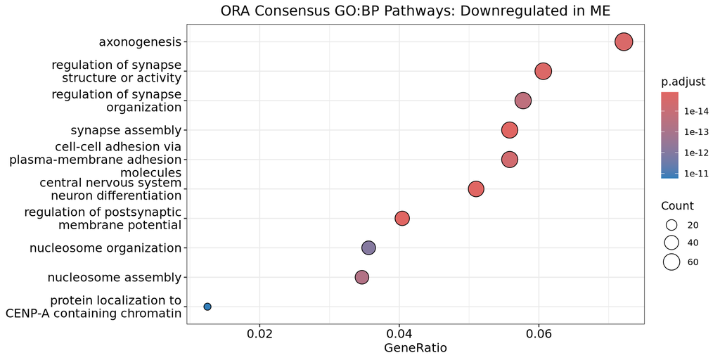

```r
ora_consensus_down_go_plot
```

#### 3.1.3. Enrich Using KEGG Database

##### 3.1.3.1. Enrich Upregulated And Downregulated Genes

```r
# strip Ensembl version suffixes before enrichment
deseq2_up_ids   <- gsub("\\..*", "", deseq2_up)
deseq2_down_ids <- gsub("\\..*", "", deseq2_down)
edger_up_ids    <- gsub("\\..*", "", edger_up)
edger_down_ids  <- gsub("\\..*", "", edger_down)


# convert Ensembl IDs to Entrez IDs for KEGG (enrichKEGG requires Entrez IDs)
deseq2_up_entrez   <- bitr(
    deseq2_up_ids,
    fromType = "ENSEMBL",
    toType = "ENTREZID",
    OrgDb = org.Hs.eg.db
  ) %>%
  distinct(ENTREZID, .keep_all = TRUE) %>%  # keep only first occurences of Entrez IDs
  pull(ENTREZID)                            # extract Entrez ID column

deseq2_down_entrez <- bitr(
    deseq2_down_ids,
    fromType = "ENSEMBL",
    toType = "ENTREZID",
    OrgDb = org.Hs.eg.db
  ) %>%
  distinct(ENTREZID, .keep_all = TRUE) %>%  # keep only first occurences of Entrez IDs
  pull(ENTREZID)                            # extract Entrez ID column

edger_up_entrez    <- bitr(
    edger_up_ids,
    fromType = "ENSEMBL",
    toType = "ENTREZID",
    OrgDb = org.Hs.eg.db
  ) %>%
  distinct(ENTREZID, .keep_all = TRUE) %>%  # keep only first occurences of Entrez IDs
  pull(ENTREZID)                            # extract Entrez ID column

edger_down_entrez  <- bitr(
    edger_down_ids,
    fromType = "ENSEMBL",
    toType = "ENTREZID",
    OrgDb = org.Hs.eg.db
  ) %>%
  distinct(ENTREZID, .keep_all = TRUE) %>%  # keep only first occurences of Entrez IDs
  pull(ENTREZID)                            # extract Entrez ID column




# ORA on DESeq2 upregulated genes
ora_deseq2_up_kegg <- enrichKEGG(
  gene          = deseq2_up_entrez,  # DESeq2 upregulated gene list (Entrez IDs)
  organism      = "hsa",             # organism is human (hsa=Homo sapiens)

  pAdjustMethod = "BH",              # correct for multiple testing using Benjamini-Hochberg FDR correction
  pvalueCutoff  = 0.05               # only consider p-values < 0.05 as significant
)

# convert Entrez IDs to gene symbols in the output
ora_deseq2_up_kegg <- setReadable(ora_deseq2_up_kegg, OrgDb = org.Hs.eg.db, keyType = "ENTREZID")



# ORA on DESeq2 downregulated genes
ora_deseq2_down_kegg <- enrichKEGG(
  gene          = deseq2_down_entrez,  # DESeq2 downregulated gene list (Entrez IDs)
  organism      = "hsa",               # organism is human (hsa=Homo sapiens)

  pAdjustMethod = "BH",                # correct for multiple testing using Benjamini-Hochberg FDR correction
  pvalueCutoff  = 0.05                 # only consider p-values < 0.05 as significant
)

# convert Entrez IDs to gene symbols in the output
ora_deseq2_down_kegg <- setReadable(ora_deseq2_down_kegg, OrgDb = org.Hs.eg.db, keyType = "ENTREZID")




# ORA on EdgeR upregulated genes
ora_edger_up_kegg <- enrichKEGG(
  gene          = edger_up_entrez,  # EdgeR upregulated gene list (Entrez IDs)
  organism      = "hsa",            # organism is human (hsa=Homo sapiens)

  pAdjustMethod = "BH",             # correct for multiple testing using Benjamini-Hochberg FDR correction
  pvalueCutoff  = 0.05              # only consider p-values < 0.05 as significant
)

# convert Entrez IDs to gene symbols in the output
ora_edger_up_kegg <- setReadable(ora_edger_up_kegg, OrgDb = org.Hs.eg.db, keyType = "ENTREZID")




# ORA on EdgeR downregulated genes
ora_edger_down_kegg <- enrichKEGG(
  gene          = edger_down_entrez,    # EdgeR downregulated gene list (Entrez IDs)
  organism      = "hsa",                # organism is human (hsa=Homo sapiens)

  pAdjustMethod = "BH",                 # correct for multiple testing using Benjamini-Hochberg FDR correction
  pvalueCutoff  = 0.05                  # only consider p-values < 0.05 as significant
)

# convert Entrez IDs to gene symbols in the output
ora_edger_down_kegg <- setReadable(ora_edger_down_kegg, OrgDb = org.Hs.eg.db, keyType = "ENTREZID")



cat("ORA KEGG results:\n")
```

```
ORA KEGG results:
```

```r
cat("DESeq2 upregulated:   ", nrow(ora_deseq2_up_kegg@result   %>% filter(p.adjust < 0.05)), "significant terms\n")
```

```
DESeq2 upregulated:    74 significant terms
```

```r
cat("DESeq2 downregulated: ", nrow(ora_deseq2_down_kegg@result %>% filter(p.adjust < 0.05)), "significant terms\n\n")
```

```
DESeq2 downregulated:  32 significant terms
```

```r
cat("EdgeR upregulated:    ", nrow(ora_edger_up_kegg@result    %>% filter(p.adjust < 0.05)), "significant terms\n")
```

```
EdgeR upregulated:     79 significant terms
```

```r
cat("EdgeR downregulated:  ", nrow(ora_edger_down_kegg@result  %>% filter(p.adjust < 0.05)), "significant terms\n")
```

```
EdgeR downregulated:   31 significant terms
```

##### 3.1.3.2. Extract Consensus Results

```r
# intersect by pathway ID, retain DESeq2's full result rows as primary statistics
ora_consensus_up_kegg <- ora_deseq2_up_kegg@result %>%
  filter(p.adjust < 0.05) %>%
  filter(ID %in% (ora_edger_up_kegg@result %>% filter(p.adjust < 0.05) %>% pull(ID)))

ora_consensus_down_kegg <- ora_deseq2_down_kegg@result %>%
  filter(p.adjust < 0.05) %>%
  filter(ID %in% (ora_edger_down_kegg@result %>% filter(p.adjust < 0.05) %>% pull(ID)))

cat("Consensus ORA KEGG terms:\n")
```

```
Consensus ORA KEGG terms:
```

```r
cat("Upregulated:  ", nrow(ora_consensus_up_kegg), "\n")
```

```
Upregulated:   74
```

```r
cat("Downregulated:", nrow(ora_consensus_down_kegg), "\n")
```

```
Downregulated: 30
```

```r
cat("\nTop 10 consensus upregulated KEGG terms:\n")
```

```
Top 10 consensus upregulated KEGG terms:
```

```r
ora_consensus_up_kegg %>%
  arrange(p.adjust) %>%
  dplyr::select(Description, p.adjust, Count) %>%
  mutate(p.adjust = formatC(p.adjust, format = "e", digits = 2)) %>%
  head(10) %>%
  knitr::kable()
```

|  | Description | p.adjust | Count |
| --- | --- | --- | --- |
| hsa04060 | Cytokine-cytokine receptor interaction | 1.56e-32 | 102 |
| hsa04061 | Viral protein interaction with cytokine and cytokine receptor | 2.96e-25 | 51 |
| hsa05323 | Rheumatoid arthritis | 9.31e-18 | 42 |
| hsa04640 | Hematopoietic cell lineage | 9.40e-18 | 43 |
| hsa04380 | Osteoclast differentiation | 1.30e-15 | 49 |
| hsa04610 | Complement and coagulation cascades | 6.61e-14 | 36 |
| hsa05150 | Staphylococcus aureus infection | 4.62e-13 | 37 |
| hsa04668 | TNF signaling pathway | 2.08e-12 | 40 |
| hsa05140 | Leishmaniasis | 7.66e-12 | 31 |
| hsa04145 | Phagocytosis | 1.15e-11 | 62 |

```r
cat("\nTop 10 consensus downregulated KEGG terms:\n")
```

```
Top 10 consensus downregulated KEGG terms:
```

```r
ora_consensus_down_kegg %>%
  arrange(p.adjust) %>%
  dplyr::select(Description, p.adjust, Count) %>%
  mutate(p.adjust = formatC(p.adjust, format = "e", digits = 2)) %>%
  head(10) %>%
  knitr::kable()
```

|  | Description | p.adjust | Count |
| --- | --- | --- | --- |
| hsa05034 | Alcoholism | 4.43e-29 | 61 |
| hsa05322 | Systemic lupus erythematosus | 6.64e-23 | 47 |
| hsa04613 | Neutrophil extracellular trap formation | 2.18e-18 | 49 |
| hsa04082 | Neuroactive ligand signaling | 9.14e-16 | 46 |
| hsa04080 | Neuroactive ligand-receptor interaction | 2.28e-11 | 57 |
| hsa04724 | Glutamatergic synapse | 1.78e-08 | 26 |
| hsa05033 | Nicotine addiction | 5.94e-07 | 14 |
| hsa04721 | Synaptic vesicle cycle | 4.98e-06 | 18 |
| hsa04024 | cAMP signaling pathway | 4.98e-06 | 33 |
| hsa04728 | Dopaminergic synapse | 6.84e-05 | 22 |

##### 3.1.3.3. Plot Consensus Results

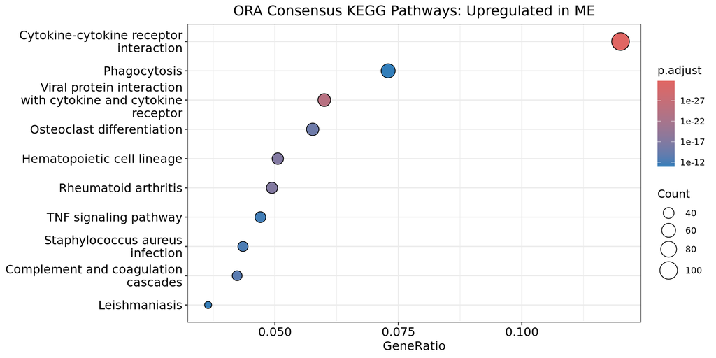

```r
# convert into dotplot()-compatible objects
ora_consensus_up_kegg_enrich_result <- new("enrichResult", result = ora_consensus_up_kegg)
ora_consensus_down_kegg_enrich_result <- new("enrichResult", result = ora_consensus_down_kegg)



# plot top 10 consensus upregulated KEGG terms
ora_consensus_up_kegg_plot   <- dotplot(
  ora_consensus_up_kegg_enrich_result,
  showCategory = 10,
  title = "ORA Consensus KEGG Pathways: Upregulated in ME"
) +
theme(plot.title = element_text(hjust = 0.5, size = 14))


# plot top 10 consensus downregulated KEGG terms
ora_consensus_down_kegg_plot   <- dotplot(
  ora_consensus_down_kegg_enrich_result,
  showCategory = 10,
  title = "ORA Consensus KEGG Pathways: Downregulated in ME"
) +
theme(plot.title = element_text(hjust = 0.5, size = 14))



ora_consensus_up_kegg_plot
```

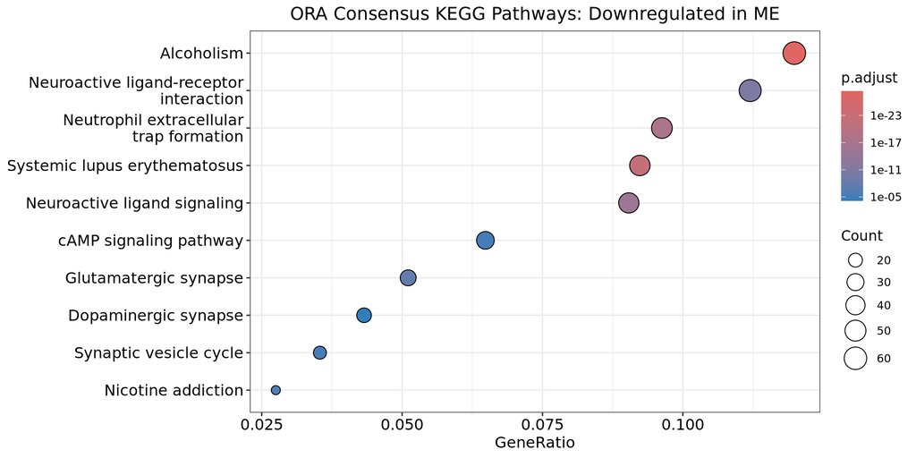

```r
ora_consensus_down_kegg_plot
```

#### 3.1.3. Combine ORA Consensus Results Plots

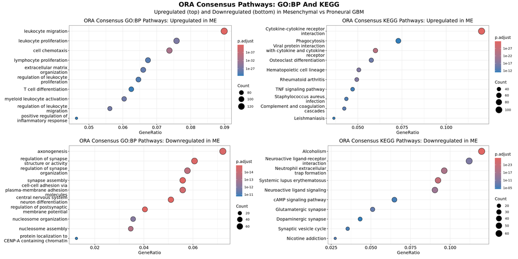

```r
ora_consensus_plots <- (ora_consensus_up_go_plot | ora_consensus_up_kegg_plot) /
                     (ora_consensus_down_go_plot | ora_consensus_down_kegg_plot) +
  plot_annotation(
    title    = "ORA Consensus Pathways: GO:BP And KEGG",
    subtitle = "Upregulated (top) and Downregulated (bottom) in Mesenchymal vs Proneural GBM",
    theme    = theme(
      plot.title    = element_text(hjust = 0.5, face = "bold", size = 18),
      plot.subtitle = element_text(hjust = 0.5, size = 14)
    )
  )

ora_consensus_plots
```

The ORA results show **two clear, opposing biological signatures** consistent with known GBM subtype biology:

**Upregulated in Mesenchymal**: Dominated by a **mesenchymal/wound-healing program**, encompassing **immune infiltration, cytokine signaling, and ECM remodeling**.

- **GO:BP**: **Immune cell recruitment and proliferation, as well as tissue remodeling programs** are active in Mesenchymal tumors.
  - **Leukocyte migration**: **White blood cells** (aka leukocytes) traveling through tissue.
  - **Cell Chemotaxis**: **Cell movement directed by chemical gradient**. Cells detect **high** **concentration** of **specific chemicals** (called **chemokines**) and move **towards** them.
  - **Myeloid cell activation**: The word ‘activation’ here refers to **immune activation**. So even though the myeloid lineage includes **red blood cells and platelets**, they are **not** **immune cells** and hence **excluded**. Hence, **immune cells of myeloid lineage** are:
    - **Granulocytes**: **Innate immunity**
      - **Eosinophils**: Release granules filled with highly **caustic, tissue-damaging proteins** to neutralize **large parasites**.
      - **Basophils**:
        - Trigger **inflammatory responses** by releasing granules filled with:
          - **Histamine**: increases blood flow to the site
          - **Heparin**: prevents blood clotting
        - **Defend against parasites**, similar to eosinophils
        - **Amplify allergic reactions**: **IgE antibodies** on basophil surface, upon detection of an allergen, trigger massive **degranulation**. This is the **cause of anaphylaxis** in severe allergies.
      - **Neutrophils**:
        - Most **abundant** granulocytes
        - **Primary** first responders
        - Neutralize **pathogens** by either:
          - **Phagocytosis**: **Engulfing** pathogens and then **digesting** **them via degranulation**
          - **NETs**: Releasing their DNA strands onto the pathogen to trap it, called **NET (Neutrophil Extracellular Trap)**.
    - **Mast cells**: **Tissue-resident** cells functionally identical to **basophils**. **Innate immunity**.
    - **Agranulocytes**
      - **Monocytes**:
        - **Macrophages:** Engulf and digest pathogens (i.e. **phagocytosis**). **Innate Immunity.**
        - **Dendritic cells:**
          - **APCs**: They are **Antigen Presenting Cells**, i.e. they **capture and process antigens**, then **‘present’ them to T cells** to initiate a **specific long-term immune memory**
          - **Bridge** between **innate and adaptive** immunity.

    Myeloid cell activation within GOBP specifically refers to activation of cells for **innate immunity**, which essentially is almost **all myeloid leukocytes**.
  - **Lymphocyte proliferation/differentiation**: Contrasting with myeloid activation, these terms reflect the proliferation and maturation of **adaptive immune cells**, which are **exclusively lymphocytes i.e. T and B cells**.
  - **Extracellular matrix (ECM) organization**: **Mesenchymal cells** are, by definition, **multipotent stem** cells that **differentiate into** **connective tissue cells.** **ECM organization** **here** means **actively remodeling and restructuring the tissue scaffold** (depositing new matrix proteins, degrading old ones, crosslinking fibers), which is a **defining activity of mesenchymal-lineage cells**, not something all cells do equally. Its **appearance here** is the **most direct molecular confirmation** that **ME tumor cells** have adopted a **mesenchymal transcriptional identity**, **not just an incidental immune signal**.
- **KEGG**: Mesenchymal tumors show **active cytokine signaling** and **innate immune effector mechanisms (complement cascades, phagocytosis, TNF/NF-κB).**
  - **Cytokine-cytokine receptor interaction**: The **primary communication network** of the **immune system.** It involves **cells releasing a signaling protein (cytokine)** and another cell catching it with a **specific molecular glove (receptor)** to trigger a reaction.
  - **TNF signaling**: **TNF-α is a cytokine** secreted mainly by **activated macrophages**, which **binds with receptors of any cell surface** (not just blood cells) for **enabling NF-κB to enter the cell nucleus**. **NF-κB is a transcription factor** that enters the nucleus and **activates genes for:**
    - **Cytokine production**
    - **Immune cell recruitment**
    - **Anti-apoptotic survival pathways**
  - **Complement cascades**: The complement system is a **cascade of proteins that assists antibodies in neutralizing pathogens**. They do so in these ways:
    - **Opsonization**: **Coating pathogens with proteins** that **attract neutrophils/macrophages** for **phagocytosis** of pathogen
    - **Lysis**: Forming the **Membrane Attack Complex (MAC),** which **punctures pathogen membranes**.
  - **Phagocytosis**

All of this reflects well-documented **characteristics of Mesenchymal GBM tumors**. What this means is:

- Bulk RNA-seq captures expression from the **entire tissue sample**, including **infiltrating immune cells alongside tumor cells**.
- **Immune infiltration** means **immune cells** from the bloodstream **physically migrate INTO the tumor tissue** and take up residence there.
- Hence the pathways seen here reflects a signal that comes **partly from the immune cells** and **partly from the tumor cells**.
- Taken together: **immune cell recruitment**, **cytokine signaling**, and **ECM remodeling** pathways collectively reflect an **active wound-healing-like program** in **Mesenchymal GBM**. In **normal tissue**, **wound healing** proceeds through **four consecutive phases**:
  - **Hemostasis:** **Blood starts to clot** around the injury site to quickly stop bleeding.
  - **Inflammation:** **Immune cells** present in the wound site/blood **kill pathogens** and **clear away dead tissue debris.**
  - **Proliferation:** **Fibroblasts** and **new blood vessels** **rapidly build and proliferate fresh, highly vascularized fleshy tissue** called **granulation tissue** to **close the wound gap**. The **cells in granulation tissue** are, like with all types of cells, **held together by theirECM**, which at this point primarily has:
    - **Jelly-like soup**: The ECM contains **hyaluronic acid**, which is a **sugar chain** that **holds massive amounts of water.**
    - **Loose, thin collagen fibers**
  - **Tissue remodeling:** The **capillaries in the granulation tissue** are then **removed**, and the **loose, thin collagen fibers** are now **replaced** with **thick, tightly-packed collagen fibers,** hence **forming scar tissue.**

  In **ME tumors,** a **pathologically distorted hybrid** of the **proliferation and tissue remodeling phases** is **permanently active.**
  - **Rigid fibrotic scaffold**: **Unlike** a **normal, organized scar**, the tumor **continuously pumps out dense collagen**. These fibers are **aggressively cross-linked** into a **rigid, highly stiffened matrix network**.
  - **Impaired, leaky blood vessels**: Simultaneously, the tumor **remains stuck in the proliferation phase’s drive for new clrculation.** It **constantly forces** the **growth of new blood vessels**. Because this signal never turns off, **these vessels are structurally malformed, immature, and highly leaky**, causing **blood plasma and fluid to flood the surrounding tissue**.
  - **Trapped inflammation**: This **combination of a stiff, altered matrix and leaky blood vessels** causes the **inflammation phase** to become **permanently active.** **Immune cells easily escape the leaky vessels into the tumor**. Once outside, rather than passing through, they **interact with matrix components** (including fragmented hyaluronic acid), which itself **happens to be a known mechanism** that **activates inflammatory signaling** that **promotes their retention.** These infiltrating cells are **then reprogrammed by the tumor**, which **suppress anti-tumor immunity** and actively **promote tumor expansion**.

  This results in the **formation of an inflamed, hardened, and highly leaky tissue mass** inside a brain environment that is **normally soft and delicate.** This **shows why ME tumors are so dangerous**, showing a phenomenon sometimes called the **“wound that never heals”** in cancer biology. The **immune infiltration and ECM signals** are therefore **not** **two** **separate** **findings** but **two components of the same underlying mesenchymal/wound-healing program** that defines the ME subtype.

**Downregulated in Mesenchymal (i.e. upregulated in Proneural)**: Dominated by **neural differentiation** and **synaptic signaling** pathways.

This reflects the **neural stem cell-like transcriptomic identity characteristic of Proneural GBM.**

The **alcoholism, lupus**, and **neutrophil extracellular trap (NET)** KEGG terms appearing in the **downregulated** list are **histone-gene artifacts as discussed in EDA,** not biologically meaningful in this context.

### 3.2. Perform GSEA

**Gene Set Enrichment Analysis (GSEA)** tests **whether genes belonging to a pre-defined pathway** tend to **cluster toward the top or bottom of a ranked gene list, rather than being scattered randomly** throughout it.

Unlike ORA, **GSEA does not require a pre-split significant gene list**. Instead, **all genes are ranked by a continuous statistic** (here, the **signed** **DESeq2 Wald statistic** and, independently, the **signed EdgeR F-statistic**), and GSEA goes down the ranked list and computes an **enrichment score that peaks where pathway genes are most concentrated**. A **positive Normalized Enrichment Score (NES)** indicates the **pathway’s genes cluster toward the top of the ranking (i.e. upregulated in ME),** while a **negative NES** indicates **clustering toward the bottom (i.e. downregulated in ME, upregulated in PN)**.

GSEA is run **separately on DESeq2’s and EdgeR’s ranked lists**, and **only consensus results are retained**. That is, **only the pathways from DESeq2 lists are retained**, that too **only if they are also significant in EdgeR lists**.

#### 3.2.1. Enrich Using GO:BP Database

##### 3.2.1.1. Enrich Full DE Results

GSEA requires a **ranked gene list**, which is prepared as follows:

- The **DESeq2 ranked gene list** is built using the **signed Wald statistic** (`stat` column from the full results), which is the **ratio of estimated log2 fold-change to standard error of each gene’s expression levels**, reflecting effect size relative to estimation uncertainty (i.e. **signal-to-noise** ratio).
- The **EdgeR ranked gene list** is built using the **signed F-statistic** (`F` column from the full results, signed by `logFC` direction), which is the **ratio of between-group variance to within-group variance of each gene’s expression levels**, reflecting the **proportion of a gene’s total variance** driven by **true biological subtype differences** relative to **baseline residual noise within its subtype group.**

```r
# build DESeq2 ranked gene list: named vector of signed Wald statistics
# stat is already signed (positive = upregulated in ME, negative = downregulated in ME)

deseq2_rank_vector <- deseq2_results %>%                  # DESeq2 full results
  rownames_to_column(var = "ensembl_id") %>%              # convert rownames from results, i.e. Ensembl IDs, into values in a new column named "ensembl_id"
  mutate(ensembl_id = gsub("\\..*", "", ensembl_id)) %>%  # strip version suffixes from Ensembl IDs
  filter(!is.na(stat)) %>%                                # remove genes with NA statistic (e.g. outliers flagged by DESeq2)
  arrange(desc(stat)) %>%                                 # sort descending for GSEA
  dplyr::select(ensembl_id, stat) %>%                     # keep only gene ID and ranking statistic
  deframe()                                               # convert to named numeric vector (Ensembl ID = name, stat = value)


# build EdgeR ranked gene list: F-statistic signed by logFC direction
edger_rank_vector <- edger_results %>%
  rownames_to_column(var = "ensembl_id") %>%     # convert rownames from results, i.e. Ensembl IDs, into values in a new column named "ensembl_id"
  mutate(
    ensembl_id = gsub("\\..*", "", ensembl_id),  # strip version suffixes from Ensembl IDs
    signed_F   = F * sign(logFC)                 # restore directionality to always-positive F-statistic
  ) %>%
  filter(!is.na(signed_F)) %>%                   # remove genes with NA statistic (e.g. outliers flagged by EdgeR)
  arrange(desc(signed_F)) %>%                    # sort descending for GSEA
  dplyr::select(ensembl_id, signed_F) %>%        # keep only gene ID and ranking statistic
  deframe()                                      # convert to named numeric vector (Ensembl ID = name, stat = value)



cat("DESeq2 rank vector length:", length(deseq2_rank_vector), "\n")
```

```
DESeq2 rank vector length: 16164
```

```r
cat("EdgeR rank vector length: ", length(edger_rank_vector), "\n")
```

```
EdgeR rank vector length:  16164
```

```r
# GSEA on DESeq2 ranked list
gsea_deseq2_go <- gseGO(
  geneList      = deseq2_rank_vector,  # DESeq2 rank vector
  OrgDb         = org.Hs.eg.db,        # human gene annotation database
  keyType       = "ENSEMBL",           # gene identifiers are in Ensembl ID format
  ont           = "BP",                # test against the GO Biological Process (BP) database

  pAdjustMethod = "BH",                # correct for multiple testing using Benjamini-Hochberg FDR correction
  pvalueCutoff  = 0.05,                # only consider p-values < 0.05 as significant
  eps           = 0,                   # allow very small p-values to be reported accurately, i.e. without rounding to 0

  verbose       = FALSE
)

# convert Ensembl IDs to gene symbols in the output
gsea_deseq2_go <- setReadable(gsea_deseq2_go, OrgDb = org.Hs.eg.db, keyType = "ENSEMBL")



# GSEA on EdgeR ranked list
gsea_edger_go <- gseGO(
  geneList      = edger_rank_vector,  # EdgeR rank vector
  OrgDb         = org.Hs.eg.db,       # human gene annotation database
  keyType       = "ENSEMBL",          # gene identifiers are in Ensembl ID format
  ont           = "BP",               # test against the GO Biological Process (BP) database

  pAdjustMethod = "BH",               # correct for multiple testing using Benjamini-Hochberg FDR correction
  pvalueCutoff  = 0.05,               # only consider p-values < 0.05 as significant
  eps           = 0,                   # allow very small p-values to be reported accurately, i.e. without rounding to 0

  verbose       = FALSE
)

# convert Ensembl IDs to gene symbols in the output
gsea_edger_go <- setReadable(gsea_edger_go, OrgDb = org.Hs.eg.db, keyType = "ENSEMBL")


cat("\nGSEA GO:BP results:\n")
```

```
GSEA GO:BP results:
```

```r
cat("DESeq2 significant pathways:", nrow(gsea_deseq2_go@result %>% filter(p.adjust < 0.05)), "\n")
```

```
DESeq2 significant pathways: 2260
```

```r
cat("EdgeR significant pathways: ", nrow(gsea_edger_go@result %>% filter(p.adjust < 0.05)), "\n")
```

```
EdgeR significant pathways:  1606
```

##### 3.2.1.2. Split Into Upregulated And Downregulated Pathways

```r
# split DESeq2 GSEA results by NES sign
gsea_deseq2_up_go   <- gsea_deseq2_go@result %>% filter(NES > 0)
gsea_deseq2_down_go <- gsea_deseq2_go@result %>% filter(NES < 0)

# split EdgeR GSEA results by NES sign
gsea_edger_up_go   <- gsea_edger_go@result %>% filter(NES > 0)
gsea_edger_down_go <- gsea_edger_go@result %>% filter(NES < 0)


cat("DESeq2 GSEA GO:BP upregulated:  ", nrow(gsea_deseq2_up_go), "\n")
```

```
DESeq2 GSEA GO:BP upregulated:   1701
```

```r
cat("DESeq2 GSEA GO:BP downregulated:", nrow(gsea_deseq2_down_go), "\n\n")
```

```
DESeq2 GSEA GO:BP downregulated: 559
```

```r
cat("EdgeR GSEA GO:BP upregulated:   ", nrow(gsea_edger_up_go), "\n")
```

```
EdgeR GSEA GO:BP upregulated:    1166
```

```r
cat("EdgeR GSEA GO:BP downregulated: ", nrow(gsea_edger_down_go), "\n")
```

```
EdgeR GSEA GO:BP downregulated:  440
```

##### 3.2.1.3. Extract Consensus Results

```r
# intersect by pathway ID, retain DESeq2's full result rows as primary statistics
gsea_consensus_up_go <- gsea_deseq2_up_go %>%
  filter(p.adjust < 0.05) %>%
  filter(ID %in% (gsea_edger_up_go %>% filter(p.adjust < 0.05) %>% pull(ID)))

gsea_consensus_down_go <- gsea_deseq2_down_go %>%
  filter(p.adjust < 0.05) %>%
  filter(ID %in% (gsea_edger_down_go %>% filter(p.adjust < 0.05) %>% pull(ID)))

cat("Consensus GSEA GO:BP terms before removing redundant ones:\n")
```

```
Consensus GSEA GO:BP terms before removing redundant ones:
```

```r
cat("Upregulated:  ", nrow(gsea_consensus_up_go), "\n")
```

```
Upregulated:   1146
```

```r
cat("Downregulated:", nrow(gsea_consensus_down_go), "\n")
```

```
Downregulated: 406
```

```r
# remove redundant GO terms using semantic similarity
set.seed(42)
gsea_consensus_up_go   <- simplify(
  new("gseaResult", result = gsea_consensus_up_go, setType = "BP")
)@result

set.seed(42)
gsea_consensus_down_go <- simplify(
  new("gseaResult", result = gsea_consensus_down_go, setType = "BP")
)@result

cat("Consensus GSEA GO:BP terms after removing redundant ones:\n")
```

```
Consensus GSEA GO:BP terms after removing redundant ones:
```

```r
cat("Upregulated:  ", nrow(gsea_consensus_up_go), "\n")
```

```
Upregulated:   360
```

```r
cat("Downregulated:", nrow(gsea_consensus_down_go), "\n")
```

```
Downregulated: 125
```

```r
cat("\nTop 10 consensus upregulated GO:BP terms:\n")
```

```
Top 10 consensus upregulated GO:BP terms:
```

```r
gsea_consensus_up_go %>%
  arrange(p.adjust) %>%
  dplyr::select(Description, NES, p.adjust) %>%
  mutate(
    NES      = round(NES, 3),
    p.adjust = formatC(p.adjust, format = "e", digits = 2)
  ) %>%
  head(10) %>%
  knitr::kable()
```

|  | Description | NES | p.adjust |
| --- | --- | --- | --- |
| GO:0019221 | cytokine-mediated signaling pathway | 2.960 | 1.02e-45 |
| GO:0002250 | adaptive immune response | 3.024 | 5.19e-44 |
| GO:0001819 | positive regulation of cytokine production | 2.873 | 8.37e-41 |
| GO:0002443 | leukocyte mediated immunity | 3.010 | 2.57e-38 |
| GO:0050900 | leukocyte migration | 3.006 | 2.57e-38 |
| GO:0002697 | regulation of immune effector process | 3.001 | 4.52e-38 |
| GO:0050727 | regulation of inflammatory response | 2.970 | 5.08e-37 |
| GO:0070661 | leukocyte proliferation | 3.025 | 1.93e-36 |
| GO:0007159 | leukocyte cell-cell adhesion | 2.888 | 3.28e-36 |
| GO:0060326 | cell chemotaxis | 3.086 | 7.90e-35 |

```r
cat("\nTop 10 consensus downregulated GO:BP terms:\n")
```

```
Top 10 consensus downregulated GO:BP terms:
```

```r
gsea_consensus_down_go %>%
  arrange(p.adjust) %>%
  dplyr::select(Description, NES, p.adjust) %>%
  mutate(
    NES      = round(NES, 3),
    p.adjust = formatC(p.adjust, format = "e", digits = 2)
  ) %>%
  head(10) %>%
  knitr::kable()
```

|  | Description | NES | p.adjust |
| --- | --- | --- | --- |
| GO:0007059 | chromosome segregation | -2.664 | 1.63e-26 |
| GO:0098813 | nuclear chromosome segregation | -2.649 | 1.55e-21 |
| GO:0000819 | sister chromatid segregation | -2.735 | 1.76e-19 |
| GO:0000280 | nuclear division | -2.346 | 2.45e-18 |
| GO:0006397 | mRNA processing | -2.283 | 4.58e-18 |
| GO:0071824 | protein-DNA complex organization | -2.608 | 2.72e-17 |
| GO:0033044 | regulation of chromosome organization | -2.581 | 9.32e-17 |
| GO:0065004 | protein-DNA complex assembly | -2.637 | 1.70e-16 |
| GO:0051983 | regulation of chromosome segregation | -2.830 | 2.82e-16 |
| GO:0006302 | double-strand break repair | -2.337 | 1.61e-15 |

##### 3.2.1.4. Plot Consensus Results

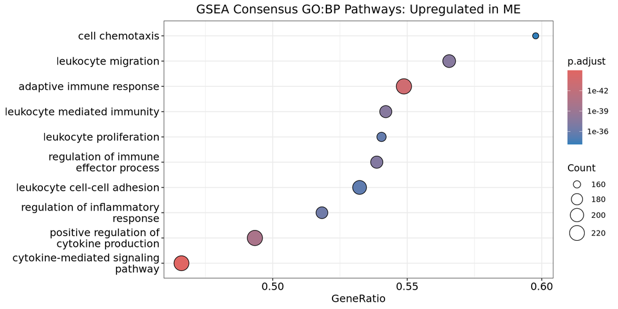

```r
# convert into dotplot()-compatible objects
gsea_consensus_up_go_enrich <- new("gseaResult", result = gsea_consensus_up_go)
gsea_consensus_down_go_enrich <- new("gseaResult", result = gsea_consensus_down_go)



# plot top 10 consensus upregulated GO:BP terms
gsea_consensus_up_go_plot   <- dotplot(
  gsea_consensus_up_go_enrich,
  showCategory = 10,
  title = "GSEA Consensus GO:BP Pathways: Upregulated in ME"
) +
theme(plot.title = element_text(hjust = 0.5, size = 14))


# plot top 10 consensus downregulated GO:BP terms
gsea_consensus_down_go_plot   <- dotplot(
  gsea_consensus_down_go_enrich,
  showCategory = 10,
  title = "GSEA Consensus GO:BP Pathways: Downregulated in ME"
) +
theme(plot.title = element_text(hjust = 0.5, size = 14))



gsea_consensus_up_go_plot
```

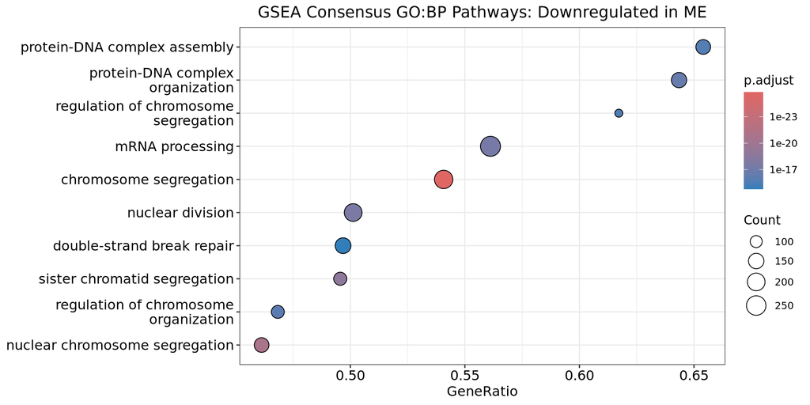

```r
gsea_consensus_down_go_plot
```

#### 3.2.2. Enrich Using KEGG Database

##### 3.2.2.1. Enrich Full DE Results

```r
# build Entrez ID ranked vectors for KEGG (enrichKEGG requires Entrez IDs)
# DESeq2
deseq2_rank_vector_entrez <- deseq2_results %>%           # DESeq2 full results
  rownames_to_column(var = "ensembl_id") %>%              # convert rownames from results, i.e. Ensembl IDs, into values in a new column named "ensembl_id"
  mutate(ensembl_id = gsub("\\..*", "", ensembl_id)) %>%  # strip version suffixes from Ensembl IDs
  filter(!is.na(stat)) %>%                                # remove genes with NA Wald statistic (e.g. outliers flagged by DESeq2)
  left_join(                                              # map Ensembl IDs to Entrez IDs (required by gseKEGG)
    bitr(
      gsub("\\..*", "", rownames(deseq2_results)),        # strip version suffixes before mapping
      fromType = "ENSEMBL",
      toType = "ENTREZID",
      OrgDb = org.Hs.eg.db
    ),
    by = c("ensembl_id" = "ENSEMBL")                      # join on the stripped Ensembl ID column
  ) %>%
  filter(!is.na(ENTREZID)) %>%                            # remove genes that failed Ensembl -> Entrez mapping
  distinct(ENTREZID, .keep_all = TRUE) %>%                # keep only first occurences of Entrez IDs
  arrange(desc(stat)) %>%                                 # sort descending by Wald statistic for GSEA
  dplyr::select(ENTREZID, stat) %>%                       # keep only gene ID and ranking statistic
  deframe()                                               # convert to named numeric vector (Entrez ID = name, stat = value)


# EdgeR
edger_rank_vector_entrez <- edger_results %>%      # EdgeR full results
  rownames_to_column(var = "ensembl_id") %>%       # convert rownames from results, i.e. Ensembl IDs, into values in a new column named "ensembl_id"
  mutate(
    ensembl_id = gsub("\\..*", "", ensembl_id),    # strip version suffixes from Ensembl IDs
    signed_F   = F * sign(logFC)                   # assign logFC direction to F statistic
  ) %>%
  filter(!is.na(signed_F)) %>%                     # remove genes with NA signed-F statistic (e.g. outliers flagged by EdgeR)
  left_join(                                       # map Ensembl IDs to Entrez IDs (required by gseKEGG)
    bitr(
      gsub("\\..*", "", rownames(edger_results)),  # strip version suffixes before mapping
      fromType = "ENSEMBL",
      toType = "ENTREZID",
      OrgDb = org.Hs.eg.db
    ),
    by = c("ensembl_id" = "ENSEMBL")               # join on the stripped Ensembl ID column
  ) %>%
  filter(!is.na(ENTREZID)) %>%                     # remove genes that failed Ensembl -> Entrez mapping
  distinct(ENTREZID, .keep_all = TRUE) %>%                # keep only first occurences of Entrez IDs
  arrange(desc(signed_F)) %>%                      # sort descending by signed-F statistic for GSEA
  dplyr::select(ENTREZID, signed_F) %>%            # keep only gene ID and ranking statistic
  deframe()                                        # convert to named numeric vector (Entrez ID = name, stat = value)



cat("DESeq2 Entrez rank vector length:", length(deseq2_rank_vector_entrez), "\n")
```

```
DESeq2 Entrez rank vector length: 16190
```

```r
cat("EdgeR Entrez rank vector length: ", length(edger_rank_vector_entrez), "\n")
```

```
EdgeR Entrez rank vector length:  16190
```

```r
# GSEA on DESeq2 ranked list
gsea_deseq2_kegg <- gseKEGG(
  geneList      = deseq2_rank_vector_entrez,  # DESeq2 full results (Entrez IDs)
  organism      = "hsa",                      # organism is human (hsa=Homo sapiens)

  pAdjustMethod = "BH",                       # correct for multiple testing using Benjamini-Hochberg FDR correction
  pvalueCutoff  = 0.05,                       # only consider p-values < 0.05 as significant
  eps           = 0,                          # allow very small p-values to be reported accurately, i.e. without rounding to 0

  verbose       = FALSE
)

# convert Entrez IDs to gene symbols in the output
gsea_deseq2_kegg <- setReadable(gsea_deseq2_kegg, OrgDb = org.Hs.eg.db, keyType = "ENTREZID")





# GSEA on EdgeR ranked list
gsea_edger_kegg <- gseKEGG(
  geneList      = edger_rank_vector_entrez,  # EdgeR full results (Entrez IDs)
  organism      = "hsa",                     # organism is human (hsa=Homo sapiens)

  pAdjustMethod = "BH",                      # correct for multiple testing using Benjamini-Hochberg FDR correction
  pvalueCutoff  = 0.05,                      # only consider p-values < 0.05 as significant
  eps           = 0,                         # allow very small p-values to be reported accurately, i.e. without rounding to 0

  verbose       = FALSE
)

# convert Entrez IDs to gene symbols in the output
gsea_edger_kegg <- setReadable(gsea_edger_kegg, OrgDb = org.Hs.eg.db, keyType = "ENTREZID")



cat("\nGSEA KEGG results:\n")
```

```
GSEA KEGG results:
```

```r
cat("DESeq2 significant pathways:", nrow(gsea_deseq2_kegg@result %>% filter(p.adjust < 0.05)), "\n")
```

```
DESeq2 significant pathways: 151
```

```r
cat("EdgeR significant pathways: ", nrow(gsea_edger_kegg@result %>% filter(p.adjust < 0.05)), "\n")
```

```
EdgeR significant pathways:  126
```

##### 3.2.2.2. Split Into Upregulated And Downregulated Pathways

```r
# split DESeq2 GSEA results by NES sign
gsea_deseq2_up_kegg   <- gsea_deseq2_kegg@result %>% filter(NES > 0)
gsea_deseq2_down_kegg <- gsea_deseq2_kegg@result %>% filter(NES < 0)

# split EdgeR GSEA results by NES sign
gsea_edger_up_kegg   <- gsea_edger_kegg@result %>% filter(NES > 0)
gsea_edger_down_kegg <- gsea_edger_kegg@result %>% filter(NES < 0)


cat("DESeq2 GSEA KEGG upregulated:  ", nrow(gsea_deseq2_up_kegg), "\n")
```

```
DESeq2 GSEA KEGG upregulated:   125
```

```r
cat("DESeq2 GSEA KEGG downregulated:", nrow(gsea_deseq2_down_kegg), "\n\n")
```

```
DESeq2 GSEA KEGG downregulated: 26
```

```r
cat("EdgeR GSEA KEGG upregulated:   ", nrow(gsea_edger_up_kegg), "\n")
```

```
EdgeR GSEA KEGG upregulated:    100
```

```r
cat("EdgeR GSEA KEGG downregulated: ", nrow(gsea_edger_down_kegg), "\n")
```

```
EdgeR GSEA KEGG downregulated:  26
```

##### 3.2.2.3. Extract Consensus Results

```r
# intersect by pathway ID, retain DESeq2's full result rows as primary statistics
gsea_consensus_up_kegg <- gsea_deseq2_up_kegg %>%
  filter(p.adjust < 0.05) %>%
  filter(ID %in% (gsea_edger_up_kegg %>% filter(p.adjust < 0.05) %>% pull(ID)))

gsea_consensus_down_kegg <- gsea_deseq2_down_kegg %>%
  filter(p.adjust < 0.05) %>%
  filter(ID %in% (gsea_edger_down_kegg %>% filter(p.adjust < 0.05) %>% pull(ID)))



cat("Consensus GSEA KEGG terms:\n")
```

```
Consensus GSEA KEGG terms:
```

```r
cat("Upregulated:  ", nrow(gsea_consensus_up_kegg), "\n")
```

```
Upregulated:   97
```

```r
cat("Downregulated:", nrow(gsea_consensus_down_kegg), "\n")
```

```
Downregulated: 22
```

```r
cat("\nTop 10 consensus upregulated KEGG terms:\n")
```

```
Top 10 consensus upregulated KEGG terms:
```

```r
gsea_consensus_up_kegg %>%
  arrange(p.adjust) %>%
  dplyr::select(Description, NES, p.adjust) %>%
  mutate(
    NES      = round(NES, 3),
    p.adjust = formatC(p.adjust, format = "e", digits = 2)
  ) %>%
  head(10) %>%
  knitr::kable()
```

|  | Description | NES | p.adjust |
| --- | --- | --- | --- |
| hsa04060 | Cytokine-cytokine receptor interaction | 2.934 | 2.79e-26 |
| hsa04061 | Viral protein interaction with cytokine and cytokine receptor | 3.070 | 1.10e-18 |
| hsa04621 | NOD-like receptor signaling pathway | 2.746 | 2.34e-17 |
| hsa05150 | Staphylococcus aureus infection | 3.062 | 4.09e-17 |
| hsa04380 | Osteoclast differentiation | 2.800 | 4.09e-17 |
| hsa04640 | Hematopoietic cell lineage | 2.947 | 1.64e-16 |
| hsa04610 | Complement and coagulation cascades | 2.984 | 1.98e-16 |
| hsa04064 | NF-kappa B signaling pathway | 2.796 | 1.54e-15 |
| hsa05168 | Herpes simplex virus 1 infection | 2.642 | 3.30e-15 |
| hsa05152 | Tuberculosis | 2.630 | 4.72e-15 |

```r
cat("\nTop 10 consensus downregulated KEGG terms:\n")
```

```
Top 10 consensus downregulated KEGG terms:
```

```r
gsea_consensus_down_kegg %>%
  arrange(p.adjust) %>%
  dplyr::select(Description, NES, p.adjust) %>%
  mutate(
    NES      = round(NES, 3),
    p.adjust = formatC(p.adjust, format = "e", digits = 2)
  ) %>%
  head(10) %>%
  knitr::kable()
```

|  | Description | NES | p.adjust |
| --- | --- | --- | --- |
| hsa04110 | Cell cycle | -2.412 | 1.06e-10 |
| hsa03040 | Spliceosome | -2.164 | 5.45e-08 |
| hsa03013 | Nucleocytoplasmic transport | -2.164 | 9.03e-07 |
| hsa03082 | ATP-dependent chromatin remodeling | -2.135 | 9.32e-07 |
| hsa03460 | Fanconi anemia pathway | -2.292 | 5.50e-06 |
| hsa05034 | Alcoholism | -1.966 | 6.32e-06 |
| hsa04724 | Glutamatergic synapse | -1.992 | 2.08e-05 |
| hsa05033 | Nicotine addiction | -2.191 | 6.25e-05 |
| hsa04082 | Neuroactive ligand signaling | -1.767 | 2.09e-04 |
| hsa03083 | Polycomb repressive complex | -1.929 | 2.12e-04 |

##### 3.2.2.4. Plot Consensus Results

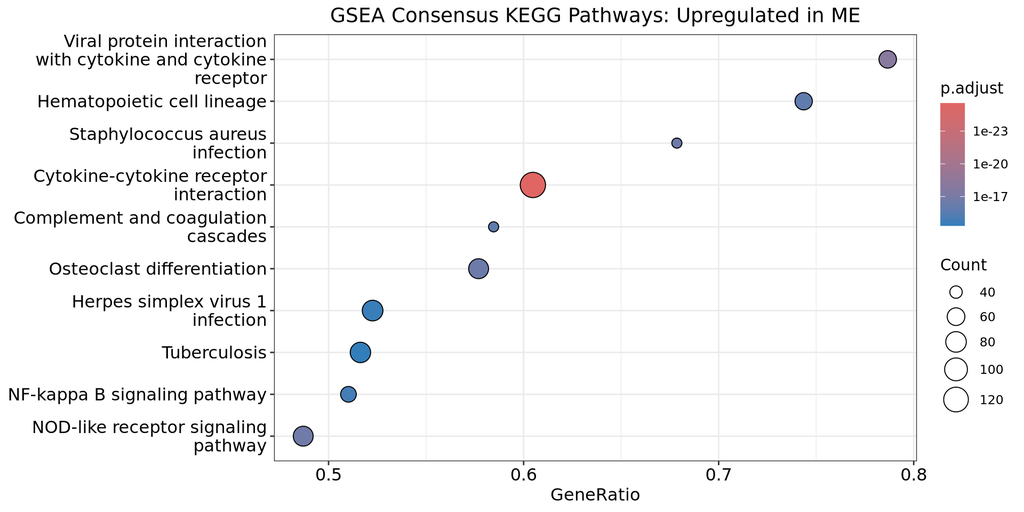

```r
# convert into dotplot()-compatible objects
gsea_consensus_up_kegg_gsea_result <- new("gseaResult", result = gsea_consensus_up_kegg)
gsea_consensus_down_kegg_gsea_result <- new("gseaResult", result = gsea_consensus_down_kegg)



# plot top 10 consensus upregulated KEGG terms
gsea_consensus_up_kegg_plot   <- dotplot(
  gsea_consensus_up_kegg_gsea_result,
  showCategory = 10,
  title = "GSEA Consensus KEGG Pathways: Upregulated in ME"
) +
theme(plot.title = element_text(hjust = 0.5, size = 14))


# plot top 10 consensus downregulated KEGG terms
gsea_consensus_down_kegg_plot   <- dotplot(
  gsea_consensus_down_kegg_gsea_result,
  showCategory = 10,
  title = "GSEA Consensus KEGG Pathways: Downregulated in ME"
) +
theme(plot.title = element_text(hjust = 0.5, size = 14))



gsea_consensus_up_kegg_plot
```

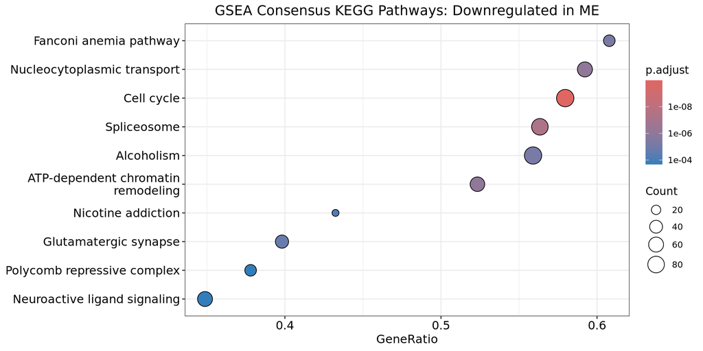

```r
gsea_consensus_down_kegg_plot
```

#### 3.2.3. Combine GSEA Consensus Results Plots

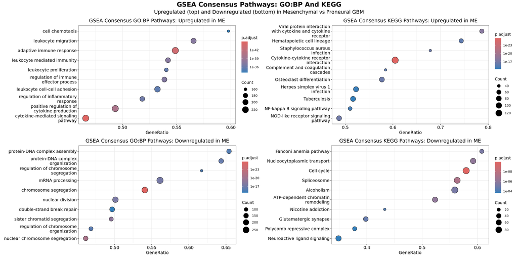

```r
gsea_consensus_plots <- (gsea_consensus_up_go_plot | gsea_consensus_up_kegg_plot) /
                     (gsea_consensus_down_go_plot | gsea_consensus_down_kegg_plot) +
  plot_annotation(
    title    = "GSEA Consensus Pathways: GO:BP And KEGG",
    subtitle = "Upregulated (top) and Downregulated (bottom) in Mesenchymal vs Proneural GBM",
    theme    = theme(
      plot.title    = element_text(hjust = 0.5, face = "bold", size = 18),
      plot.subtitle = element_text(hjust = 0.5, size = 14)
    )
  )

gsea_consensus_plots
```

The GSEA results, split by enrichment direction, **largely** **reinforce the ORA findings** while **revealing the proliferation and DNA damage response signals first identified in EDA’s PC1**.

- **Upregulated in Mesenchymal** **confirms** the **same** **mesenchymal/wound-healing signature** as **ORA**:
  - **Cytokine signaling**
  - **Leukocyte migration and cell adhesion** (cell adhesion: process by which cells interact and attach to neighboring cells/ECM)
  - **Adaptive immunity**
  - **Regulation of inflammatory response and immune effector processes**
  - **NF-κB and NOD-like receptor signaling**
    - **NF-κB signaling pathway**: NF-κB is a transcription factor that, once activated by cytokines or immune signals, enters the nucleus and activates genes for cytokine production, immune cell recruitment, and anti-apoptotic survival pathways — consistent with the constitutively active inflammatory state of ME tumors.
    - **NOD-like receptor signaling:**
      - **NOD** stands for **Nucleotide-binding Oligomerization Domain** (**domains** are **functional, independent subunits** of a **larger protein** molecule).
      - **NOD-like receptors (NLRs)** are a **specialized family of intracellular proteins** that act as **immune sensors** within the cell’s **cytoplasm**. More accurately, NLR proteins have **both a receptor end and a signaling end**, i.e. they act like a **molecular switchboard** of immune signaling.
      - They get their name because they bind **nucleotides** (like ATP) to snap **multiple receptor proteins** together **(i.e. oligomerization)**, which **forces their signaling ends into close contact**, physically **activating and attracting immune enzymes** which then **activate the genes required to cause inflammation**.

  The **viral infection and tuberculosis KEGG terms** (Herpes, Staph aureus, tuberculosis) are further **artifacts of shared cytokine/complement genes** rather than evidence of actual infection, **consistent with the lupus/alcoholism artifacts** seen in **ORA**.
- **Downregulated in Mesenchymal (i.e. upregulated in Proneural)** reveals **signals not captured by ORA**: **active cell division**, **DNA damage response**, and **RNA/chromatin processing**.
  - **GO:BP**
    - **Chromosome segregation**
    - **Sister chromatid segregation**
    - **Nuclear division**
    - **Double strand break repair:** Since its a tumor tissue, **cells divide rapidly** and as a result **accumulate more replication errors**, consequently showing **stronger DNA repair activity**. This is **consistent with the proliferative identity of Proneural tumors**, rather than indicating genomic instability.
    - **Protein-DNA complex organization and assembly**
    - **mRNA processing**
  - **KEGG**
    - **Cell cycle**
    - **ATP-dependent chromatin remodeling**
    - **Spliceosome**
      - Spliceosomes are **complex structures** made of **proteins and snRNAs (small nuclear RNAs),** responsible for carrying out **splicing of pre-mRNA molecules**.
      - This pathway being active in proneural tumors indicates that s**plicing is highly active in the transcription of the genes upregulated in proneural tumors**, meaning that there is **even more variety due to protein isoforms**, making them **more robust in carrying out their functions** and **upholding the proneural transcriptome**.
    - **Fanconi anemia (FA)**:
      - Fanconi anemia is a **genetic disorder** where the **body’s ability to repair DNA is damaged**, so the **hematopoietic cells (HSCs) in bone marrow** divide into **blood cells** that **accumulate damages to DNA**. These cells consequently **undergo apoptosis to prevent further damage**.
      - **FA genes** are genes that are **responsible for DNA repair**. It is **contradictory naming**; they were named FA genes **because scientists observed that the** **disease of FA occurs when these genes malfunction.**
      - **FA pathway upregulation in PN indicates** that rapidly dividing **Proneural tumor cells maintain active DNA repair machinery**, consistent with sustaining **high rates of cell division without catastrophic genomic instability**.
      - This is **consistent with the double strand break repair pathway above**.
    - **Nucleocytoplasmic transport**
  - This directly **recapitulates the PC1 proliferation axis identified in EDA**, indicating **Proneural** tumors carry a **relatively stronger proliferative signature** than Mesenchymal in this comparison. The **glutamatergic synapse term reappears here** too, **reaffirming the neural identity** already established by **ORA’s downregulated results**. **Alcoholism, nicotine addiction, and polycomb repressive complex** are additional **histone-gene KEGG artifacts.**

## 4. Save Outputs

### 4.1. Save Pathway Enrichment Results

#### 4.1.1. Save ORA Results

```r
write_csv(as.data.frame(ora_consensus_up_go),     "../04_results/06_pathway_enrichment/01_ora/01_ora_consensus_upregulated_gobp.csv")
write_csv(as.data.frame(ora_consensus_up_kegg),   "../04_results/06_pathway_enrichment/01_ora/02_ora_consensus_upregulated_kegg.csv")
write_csv(as.data.frame(ora_consensus_down_go),   "../04_results/06_pathway_enrichment/01_ora/03_ora_consensus_downregulated_gobp.csv")
write_csv(as.data.frame(ora_consensus_down_kegg), "../04_results/06_pathway_enrichment/01_ora/04_ora_consensus_downregulated_kegg.csv")


cat("ORA results saved\n")
```

```
ORA results saved
```

#### 4.1.2. Save GSEA Results

```r
write_csv(gsea_consensus_up_go,   "../04_results/06_pathway_enrichment/02_gsea/01_gsea_consensus_upregulated_gobp.csv")
write_csv(gsea_consensus_up_kegg,   "../04_results/06_pathway_enrichment/02_gsea/02_gsea_consensus_upregulated_kegg.csv")
write_csv(gsea_consensus_down_go, "../04_results/06_pathway_enrichment/02_gsea/03_gsea_consensus_downregulated_gobp.csv")
write_csv(gsea_consensus_down_kegg, "../04_results/06_pathway_enrichment/02_gsea/04_gsea_consensus_downregulated_kegg.csv")

cat("GSEA results saved\n")
```

```
GSEA results saved
```

### 4.2. Save Pathway Enrichment Plots

```r
ggsave("../03_figures/06_pathway_enrichment/01_ora_consensus_plots.png",  plot = ora_consensus_plots,  width = 20, height = 10, dpi = 300)
ggsave("../03_figures/06_pathway_enrichment/02_gsea_consensus_plots.png", plot = gsea_consensus_plots, width = 20, height = 10, dpi = 300)

cat("Pathway enrichment plots saved\n")
```

```
Pathway enrichment plots saved
```

## 5. Perform Sanity Checks

```r
ora_consensus_up_go_exists     <- file.exists("../04_results/06_pathway_enrichment/01_ora/01_ora_consensus_upregulated_gobp.csv")
ora_consensus_up_kegg_exists     <- file.exists("../04_results/06_pathway_enrichment/01_ora/02_ora_consensus_upregulated_kegg.csv")
ora_consensus_down_go_exists     <- file.exists("../04_results/06_pathway_enrichment/01_ora/03_ora_consensus_downregulated_gobp.csv")
ora_consensus_down_kegg_exists     <- file.exists("../04_results/06_pathway_enrichment/01_ora/04_ora_consensus_downregulated_kegg.csv")

gsea_consensus_up_go_exists     <- file.exists("../04_results/06_pathway_enrichment/02_gsea/01_gsea_consensus_upregulated_gobp.csv")
gsea_consensus_up_kegg_exists     <- file.exists("../04_results/06_pathway_enrichment/02_gsea/02_gsea_consensus_upregulated_kegg.csv")
gsea_consensus_down_go_exists     <- file.exists("../04_results/06_pathway_enrichment/02_gsea/03_gsea_consensus_downregulated_gobp.csv")
gsea_consensus_down_kegg_exists     <- file.exists("../04_results/06_pathway_enrichment/02_gsea/04_gsea_consensus_downregulated_kegg.csv")


ora_consensus_plots_exists  <- file.exists("../03_figures/06_pathway_enrichment/01_ora_consensus_plots.png")
gsea_consensus_plots_exists <- file.exists("../03_figures/06_pathway_enrichment/02_gsea_consensus_plots.png")





cat("ORA upregulated GO:BP saved:     ", ifelse(ora_consensus_up_go_exists,     "✓", "✗"), "\n")
```

```
ORA upregulated GO:BP saved:      ✓
```

```r
cat("ORA upregulated KEGG saved:      ", ifelse(ora_consensus_up_kegg_exists,   "✓", "✗"), "\n")
```

```
ORA upregulated KEGG saved:       ✓
```

```r
cat("ORA downregulated GO:BP saved:   ", ifelse(ora_consensus_down_go_exists,   "✓", "✗"), "\n")
```

```
ORA downregulated GO:BP saved:    ✓
```

```r
cat("ORA downregulated KEGG saved:    ", ifelse(ora_consensus_down_kegg_exists, "✓", "✗"), "\n")
```

```
ORA downregulated KEGG saved:     ✓
```

```r
cat("GSEA upregulated GO:BP saved:    ", ifelse(gsea_consensus_up_go_exists,     "✓", "✗"), "\n")
```

```
GSEA upregulated GO:BP saved:     ✓
```

```r
cat("GSEA upregulated KEGG saved:     ", ifelse(gsea_consensus_up_kegg_exists,   "✓", "✗"), "\n")
```

```
GSEA upregulated KEGG saved:      ✓
```

```r
cat("GSEA downregulated GO:BP saved:  ", ifelse(gsea_consensus_down_go_exists,   "✓", "✗"), "\n")
```

```
GSEA downregulated GO:BP saved:   ✓
```

```r
cat("GSEA downregulated KEGG saved:   ", ifelse(gsea_consensus_down_kegg_exists, "✓", "✗"), "\n")
```

```
GSEA downregulated KEGG saved:    ✓
```

```r
cat("ORA combined plot saved:         ", ifelse(ora_consensus_plots_exists,  "✓", "✗"), "\n")
```

```
ORA combined plot saved:          ✓
```

```r
cat("GSEA consensus plot saved:       ", ifelse(gsea_consensus_plots_exists, "✓", "✗"), "\n")
```

```
GSEA consensus plot saved:        ✓
```

```r
if (all(ora_consensus_up_go_exists, ora_consensus_up_kegg_exists,
        ora_consensus_down_go_exists, ora_consensus_down_kegg_exists,
        gsea_consensus_up_go_exists, gsea_consensus_up_kegg_exists,
        gsea_consensus_down_go_exists, gsea_consensus_down_kegg_exists,
        ora_consensus_plots_exists, gsea_consensus_plots_exists)
    )
{
  cat("\nNotebook 06 complete — all outputs verified\n")
} else {
  cat("\nWARNING: One or more outputs missing\n")
}
```

```
Notebook 06 complete — all outputs verified
```